# What is Object Oriented Programming

As we have already mentioned in the previous chapter, Python is something called an “object- oriented programming language.”

Object Oriented Programming is an approach in programming in which properties and behaviors are bundled into individual objects. In the real world, an object has some properties and functions: so for example a car has color, model, engine type, etc. and can move, accelerate, brake, etc. whereas a person has a name, height, weight, address and can walk, talk, laugh, etc.

We can have the same approach in desigining programs based on objects that represent both properties and functions that can be applied to those properties. Using Object Oriented Programming, you can add consistency to your programs so that they can be (re)used in a cleaner and more efficient way, or at least that’s the theory.

## Classes, Instances, Attributes and Methods

Classes and objects are the two main aspects of object oriented programming. A class creates a new entity where objects are instances of the class. So for example a Person would be a certain class (it is an entity) whereas Sarah, Peter and Rob (all of which are humans) - are individual instances (=objects) of the class Person.

Classes also allow us to define any needed properties (=attributes) and functions (=methods) that the object will contain. Like when Sara (= object) with 170 cm height (=attribute) that can talk (=method) is an instance of the Person class.

To summarize, a class is a structure in Python that can be used as a blueprint to create objects that have

- prototyped features, "attributes" that are variable
- "methods" which are functions that can be applied to the object that is created, or rather, an instance of that class.

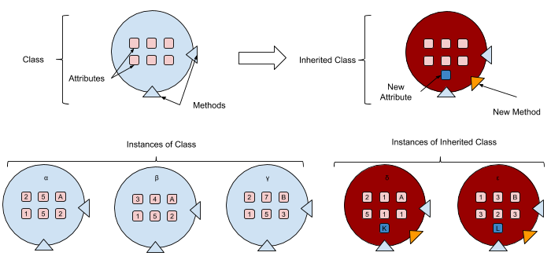

## Defining a Class

We want to define a class called *Client* in which a new instance stores a client's name, balance, and account level of a bank. It will take the format of:

```
class Client(object):
    def __init__(self, args[, ...])
        #more code
```

"def `__init__`" is what we use when creating classes to define how we can create a new instance of this class.

The arguments of `__init__` are required input when creating a new instance of this class, except for 'self'.

```python
# create the Client class below
class Client(object):
    def __init__(self, name, balance):
        self.name = name
        self.balance = balance + 100

        #define account level
        if self.balance < 5000:
            self.level = "Basic"
        elif self.balance < 15000:
            self.level = "Intermediate"
        else:
            self.level = "Advanced"
```

The **attributes** in *Client* are *name, balance* and *level*.

**Note**: "self.name" and "name" are different variables. Here they represent the same values, but in other cases, this may lead to problems. For example, here the bank has decided to update "self.balance" by giving all new members a bonus $100 on top of what they're putting in the bank. Calling "balance" for other calculations will not have the correct value.

### Creating an Instance of a Class

Now, lets try creating some new clients named John_Doe, and Jane_Defoe:

```python
John_Doe = Client("John Doe", 500)
Jane_Defoe = Client("Jane Defoe", 150000)
```

We can see the attributes of John_Doe, or Jane_Defoe by calling them:

```python
John_Doe.name
Jane_Defoe.level
Jane_Defoe.balance
```

```
150100
```

We can also add, remove or modify attributes as we like:

```python
John_Doe.email = "jdoe23@gmail.com"
John_Doe.email = "johndoe23@gmail.com"
del John_Doe.email
```

```python
getattr(John_Doe, 'name')
setattr(John_Doe, 'email', 'jdoe23@gmail.com')
John_Doe.email
```

```
'jdoe23@gmail.com'
```

You can also use the following instead instead of the normal statements:

- The `getattr(obj, name[, default])` : to access the attribute of object.
- The `hasattr(obj,name)` : to check if an attribute exists or not.
- The `setattr(obj,name,value)` : to set an attribute. If attribute does not exist, then it would be created.
- The `delattr(obj, name)` : to delete an attribute.

### Class Attributes vs. Normal Attributes

A class attribute is an attribute set at the class-level rather than the instance-level, such that the value of this attribute will be the same across all instances.

For our *Client* class, we might want to set the name of the bank, and the location, which would not change from instance to instance.

```python
Client.bank = "TD"
Client.location = "Toronto, ON"
```

```python
# try calling these attributes at the class and instance level
Client.bank
Jane_Defoe.bank
```

```
'TD'
```

### Methods

*Methods* are functions that can be applied (only) to instances of your class.

For example, in the case of our 'Client' class, we may want to update a person's bank account once they withdraw or deposit money. Let's create these methods below.

Note that each method takes 'self' as an argument along with the arguments required when calling this method.

```python
# Use the Client class code above to now add methods for withdrawal and depositing of money

# create the Client class below
class Client(object):
    def __init__(self, name, balance):
        self.name = name
        self.balance = balance + 100

        #define account level
        if self.balance < 5000:
            self.level = "Basic"
        elif self.balance < 15000:
            self.level = "Intermediate"
        else:
            self.level = "Advanced"

    def deposit(self, amount):
        self.balance += amount
        return self.balance

    def withdraw(self, amount):
        if amount > self.balance:
            raise RuntimeError("Insufficient for withdrawal")
        else:
            self.balance -= amount
        return self.balance
```

```python
Jane_Defoe = Client("Jane Defoe", 150000)
John_Doe = Client("John Doe", 500)

Jane_Defoe.deposit(150000)
```

```
300100
```

#### What is "self"?

`*`*not in the philosophical sense*`*`

In the method, withdraw(self, amount), the self refers to the *instance* upon which we are applying the instructions of the method.

When we call a method, `f(self, arg)`, on the object `x`, we use `x.f(arg)`.

- `x` is passed as the first argument, *self*, by default and all that is required are the other arguments that comprise the function.

It is equivalent to calling `MyClass.f(x, arg)`. Try it yourself with the Client class and one of the methods we've written.

```python
# Try calling a method two different ways
John_Doe.deposit(500)
Client.withdraw(Jane_Defoe, 50000)
```

[output not shown]

### Static Methods

Static methods are methods that belong to a class but do not have access to *self* and hence don't require an instance to function (i.e. it will work on the class level as well as the instance level).

We denote these with the line `@staticmethod` before we define our static method.

Let's create a static method called make_money_sound() that will simply print "Cha-ching!" when called.

```python
# Add a static method called make_money_sound()
# create the Client class below
class Client(object):
    def __init__(self, name, balance):
        self.name = name
        self.balance = balance + 100

        #define account level
        if self.balance < 5000:
            self.level = "Basic"
        elif self.balance < 15000:
            self.level = "Intermediate"
        else:
            self.level = "Advanced"

    @staticmethod
    def make_money_sound():
        print("Cha-ching!")
```

```python
Client.make_money_sound()
```

```
Cha-ching!
```

### Class Methods

A class method is a type of method that will receive the class rather than the instance as the first parameter. It is also identified similarly to a static method, with `@classmethod`.

Create a class method called bank_location() that will print both the bank name and location when called upon the class.

```python
# Add a class method called bank_location()
# create the Client class below
class Client(object):
    bank = "TD"
    location = "Toronto, ON"

    def __init__(self, name, balance):
        self.name = name
        self.balance = balance + 100

        #define account level
        if self.balance < 5000:
            self.level = "Basic"
        elif self.balance < 15000:
            self.level = "Intermediate"
        else:
            self.level = "Advanced"

    @classmethod
    def bank_location(cls):
        return str(cls.bank + " " + cls.location)
```

```python
Client.bank_location()
```

```
'TD Toronto, ON'
```

### Key Concept: Inheritance

A 'child' class can be created from a 'parent' class, whereby the child will bring over attributes and methods that its parent has, but where new features can be created as well.

This would be useful if you want to create multiple classes that would have some features that are kept the same between them. You would simply create a parent class of these children classes that have those maintained features.

Imagine we want to create different types of clients but still have all the base attributes and methods found in client currently.

For example, let's create a class called *Savings* that inherits from the *Client* class. In doing so, we do not need to write another `__init__` method as it will inherit this from its parent.

```python
# create the Savings class below
class Savings(Client):
    interest_rate = 0.005

    def update_balance(self):
        self.balance += self.balance*self.interest_rate
        return self.balance
```

```python
# create an instance the same way as a Client but this time by calling Savings instead
Lina_Tran = Savings("Lina Tran", 50)
```

```python
# it now has access to the new attributes and methods in Savings...
print(Lina_Tran.name)
print(Lina_Tran.balance)
print(Lina_Tran.interest_rate)
```

```
Lina Tran
150
0.005
```

```python
# ...as well as access to attributes and methods from the Client class as well
Lina_Tran.update_balance()
```

```
150.75
```

```python
#defining a method outside the class definition
def check_balance(self):
    return self.balance

Client.check_balance = check_balance
```

```python
John_Doe = Client("John Doe", 500)
John_Doe.check_balance()
```

```
600
```